# FMWT_SMSCG

Rosemary Hartman

7/12/2019

In the Delta Smelt Resiliancy strategy, there is the idea we can change the operation of the Suisun Marsh Salinity control gates to improve habitat in the marsh for Delta Smelt. I was curious if there were any trends between historical gate operations and presence of Delta Smelt in the Marsh. Therefore, I decided to compare catch of Delta Smelt in the marsh during the fall (when the gates are most frequently operated) with gate operations.

First I did some data manipulation to get the gate operation data lined up with the Delta Smelt Catch from the Fall Midwater Trawl, and I calculated CPUE.

FMWT data is avaialable here: ftp://ftp.wildlife.ca.gov/TownetFallMidwaterTrawl/FMWT%20Data/ Michael Koohafman gave me the gate operation data.

```r
#uplaod the fish catch data

FMWT <- read_excel("FMWT 1967-2018 Catch Matrix_updated.xlsx", sheet = "FlatFile",
                   col_types = c("numeric","date", "numeric", "text", "date",
                                 "numeric", "numeric", "numeric", "numeric", "numeric", "numeric",
                                 "numeric", "numeric", "text", "text", "text", rep("numeric", times =112)))

#put it in long format instead of wide
FMWTl = gather(FMWT, key = "Species", value = "catch", `Aequorea spp.`:`Yellowfin Goby`)

#rename all the stupid names
#names(FMWTl)
names(FMWTl) = c("Year" ,"Date","Survey","Station", "StartTime","Index",
                 "TopTemp", "TopEC","BottomEC","Turb",
                 "Secchi" , "Depthft","TowVolume","Tide","TowDirection",
                 "Weather","Microcystis","Wave", "Species" , "catch" )

#Ideally, we'd do this analysis on CPUE instead of raw catch
#They didn't caculate volumes until later, so I'll use the average
#volume per station for the older tows

#first replace any zero volumes with NAs, because zero volumes don't make sense
FMWTl$TowVolume[which(FMWTl$TowVolume==0)] = NA

#Calculate the average volume
meanvol = group_by(FMWTl, Station) %>% summarize(mvol = mean(TowVolume, na.rm = T))
FMWTl2 = merge(FMWTl, meanvol)
FMWTl2$TowVolume[which(is.na(FMWTl2$TowVolume))] = FMWTl2$mvol[which(is.na(FMWTl2$TowVolume))]

#Calculate CPUE
FMWTl2 = mutate(FMWTl2, CPUE = catch*TowVolume)

#For starters, I'll just look at Delta Smelt
FMWT_DS = filter(FMWTl2, Species == "Delta Smelt")

#Just Delta Smelt from the stations in MOntezuma Slough
FMWT_DSm = filter(FMWT_DS, Station == 605 |Station == 606| Station == 608 )

#Let's filter it so that we just look at 1999-2011. The Delta Smelt catch from
#2012-2017 was so low it's just going to throw things off

FMWT_DSm = filter(FMWT_DSm, Year < 2012)

#load the water quality and gate operations data
load("~/salinity control gates/SMSCG/operations.RData")
load("~/salinity control gates/SMSCG/waterquality.RData")

#merge the gate operations with the fish data
FMWT_DSm$Date = as.Date(FMWT_DSm$Date)
op.daily$Date = as.Date(op.daily$Date)
FMWT_DSmg = merge(FMWT_DSm, op.daily, by = "Date", all.x = T)

#make a new variable for "day of the year"
FMWT_DSmg$julian = yday(FMWT_DSmg$Date)

#Operation is a factor, not a number
FMWT_DSmg$Operating = as.factor(FMWT_DSmg$Operating)
```

Now for some quick exploritory plots of the data. Look at when the gates are usually operated and what the fish catch was like when they are or are not operated.

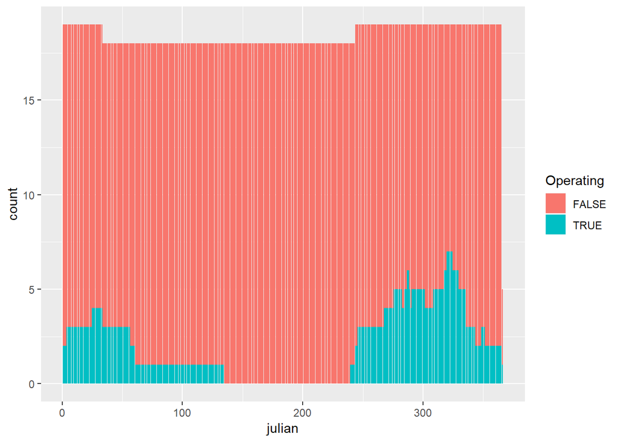

```r
#when are the gates operated?
op.daily$julian = yday(op.daily$Date)
ggplot(op.daily, aes(x=julian, fill = Operating)) + geom_bar(stat = "Count")
```

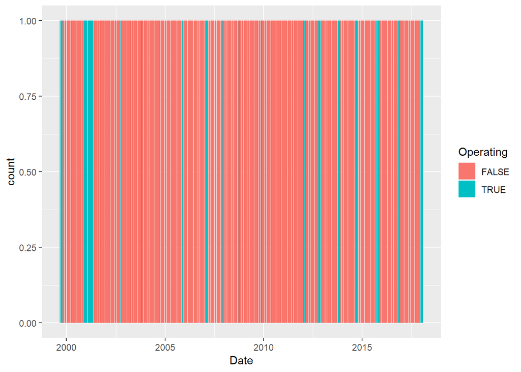

```r
ggplot(op.daily, aes(x=Date, fill = Operating)) + geom_bar(stat = "Count")
```

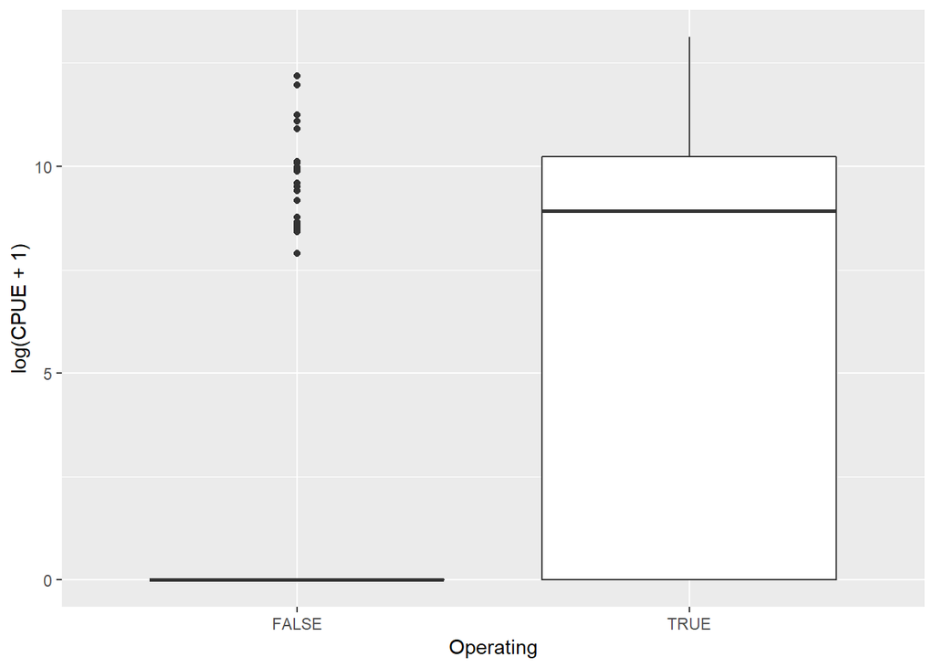

```r
#now with fish, first just the time we have gate data, and just the fall because we have more trawls in the fall
FMWT_DSmg2 = filter(FMWT_DSmg, !is.na(Operating), julian >200)
#Log CPUE versus gate operations
ggplot(FMWT_DSmg2, aes(x = Operating, y = log(CPUE+1))) + geom_boxplot()
```

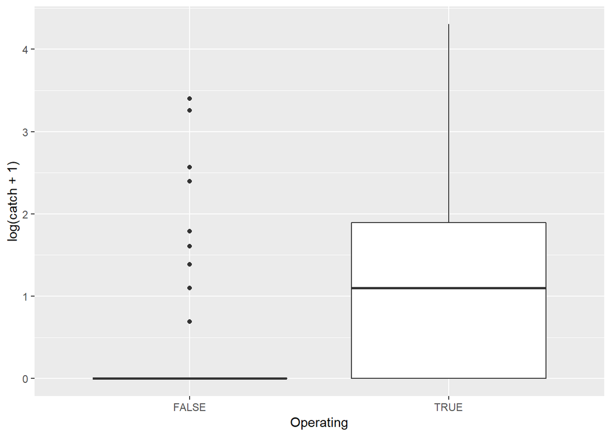

```r
#try log catch instead of CPUE
ggplot(FMWT_DSmg2, aes(x = Operating, y = log(catch+1))) + geom_boxplot()
```

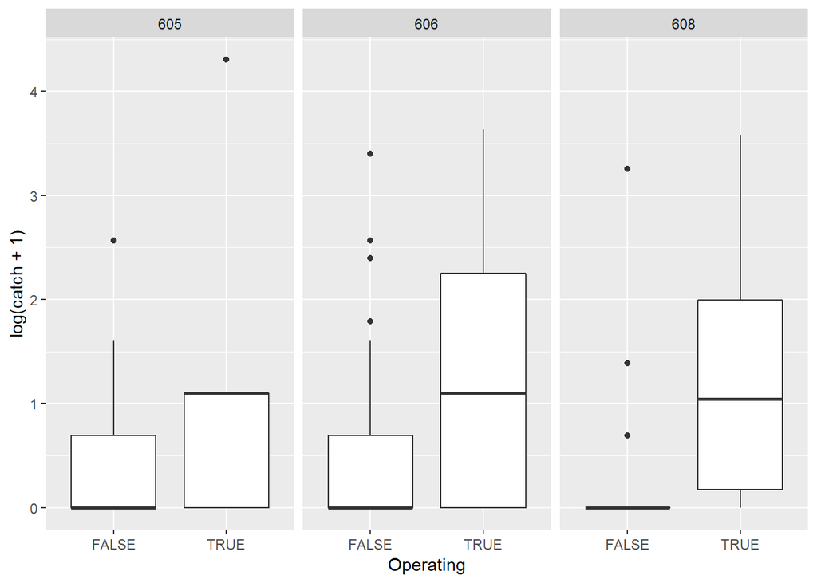

```r
#seperate by station
ggplot(FMWT_DSmg2, aes(x = Operating, y = log(catch+1))) + geom_boxplot() + facet_wrap(~Station)
```

Let’s run some models to see whether there are statisticall more smelt when the gates are operating. Other things are probably involved too, such as year, water year type, salinity, station, day of the year, etc. I’ll run several models and rank them with AICc to see which is best.